# Analiza oraz modelowanie wystąpienia cukrzycy

#### Tuning modeli

W tej części pracy przeprowadzona zostanie optymalizacja parametrów najlepszego modelu. Do optymalizacji zostanie wykorzystana metoda przeszukiwania siatki. Tuningowany będzie model lasu losowego.

```r
rf <- rand_forest(mode = "classification",
                  engine = "ranger",
                  mtry = tune(),
                  trees = tune(),
                  min_n = tune())
rf_param <- extract_parameter_set_dials(rf)
rf_param

rf_param <- finalize(rf_param, df_train)
rf_param
```

```r
rf_wf <- workflow() |>
  add_recipe(rec) |>
  add_model(rf)
```

```r
rf_search <- rf_wf |>
  tune_grid(resamples = folds, metrics = metrics)
```

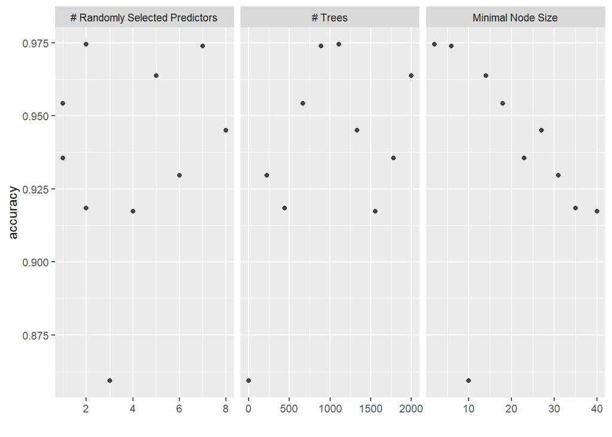

```r
autoplot(rf_search, type = 'marginals', metric = 'accuracy')
```

```r
show_best(rf_search, metric = "accuracy")
```

```
# A tibble: 5 × 9
   mtry trees min_n .metric  .estimator  mean     n std_err .config
  <int> <int> <int> <chr>    <chr>      <dbl> <int>   <dbl> <chr>
1     2  1111     2 accuracy binary     0.974     5 0.00274 Preprocessor1_Model…
2     7   889     6 accuracy binary     0.974     5 0.00371 Preprocessor1_Model…
3     5  2000    14 accuracy binary     0.964     5 0.00585 Preprocessor1_Model…
4     1   667    18 accuracy binary     0.954     5 0.00284 Preprocessor1_Model…
5     8  1333    27 accuracy binary     0.945     5 0.00354 Preprocessor1_Model…
```

#### Ocena dopasowania modelu końcowego

Jako najlepsze hiperparametry modelu zostaną wybrane te na pozycji pierwszej.

```r
best_params <- select_best(rf_search, metric = "accuracy")

final_wf <- rf_wf |>
  finalize_workflow(best_params)

final_wf
```

```
══ Workflow ════════════════════════════════════════════════════════════════════
Preprocessor: Recipe
Model: rand_forest()

── Preprocessor ────────────────────────────────────────────────────────────────
1 Recipe Step

• step_normalize()

── Model ───────────────────────────────────────────────────────────────────────
Random Forest Model Specification (classification)

Main Arguments:
  mtry = 2
  trees = 1111
  min_n = 2

Computational engine: ranger
```

Dopasowanie do zbioru testowego.

```r
final_fit <- final_wf |>
  last_fit(split)

final_fit$.metrics
```

```
[[1]]
# A tibble: 3 × 4
  .metric     .estimator .estimate .config
  <chr>       <chr>          <dbl> <chr>
1 accuracy    binary        0.978  Preprocessor1_Model1
2 roc_auc     binary        0.997  Preprocessor1_Model1
3 brier_class binary        0.0208 Preprocessor1_Model1
```

Dopasowanie do danych testowych na podstawie miary *accuracy* wynosi 97%. Pole pod krzywą ROC wynosi niemal 1.

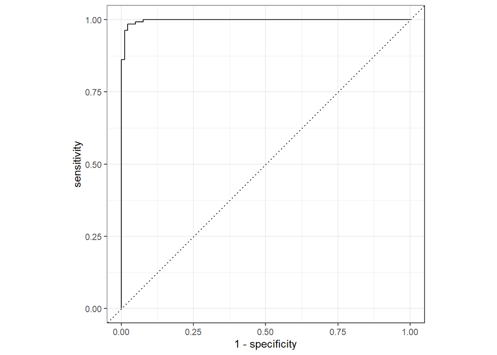

```r
final_fit$.predictions[[1]]  |>
  roc_curve(truth = Outcome, .pred_0) |>
  autoplot()
```

Poniżej przedstawiono macierz klasyfikacji.

```r
final_fit$.predictions[[1]] |>
  conf_mat(truth = Outcome, estimate = .pred_class)
```

```
          Truth
Prediction   0   1
         0 534  10
         1   8 253
```

## Podsumowanie

W wyniku modelowania udało się zbudować (stuningowany) model lasu losowego skutecznie (w 97% na danych testowych) klasyfikującego pacjentki chore na cukrzycę.